# JOUR698 Final Project

YiranZ

2025-05-10

# 4B Movement in the English-Speaking World

The 4B movement is a radical feminist movement that originated in South Korea between 2017 and 2019 (Lee & Jeong 2021). It advocates for four principles: no dating, no sex, no childbirth, and no marriage with men. This movement aims to reject traditional gender roles and challenge patriarchal culture. In this project, I aim to explore the 4B movement in the English-speaking world, particularly in the United States.

My key **research questions** are:  
1. How is the 4B movement reported by mainstream media?  
2. What are participants of the 4B movement discussing in online spaces?

**Data**:  
I used data from newspaper articles and Reddit discussions.  
1. **Newspaper**: I searched for “4B movement” in NexisUni and found 317 English-language articles published in North America before February 5th, 2025. After removing duplicates and excluding articles that did not mention the movement in the main body, the final sample size for newspaper articles is **238**.  
2. **Reddit**: I also collected posts and comments from the “4Bmovement” subreddit between April 1st and May 1st, 2025. The final sample size for online discussions is **6,773**.

## Result 1: Trend – Is 4B a Real Thing?

### Trends of Newspaper

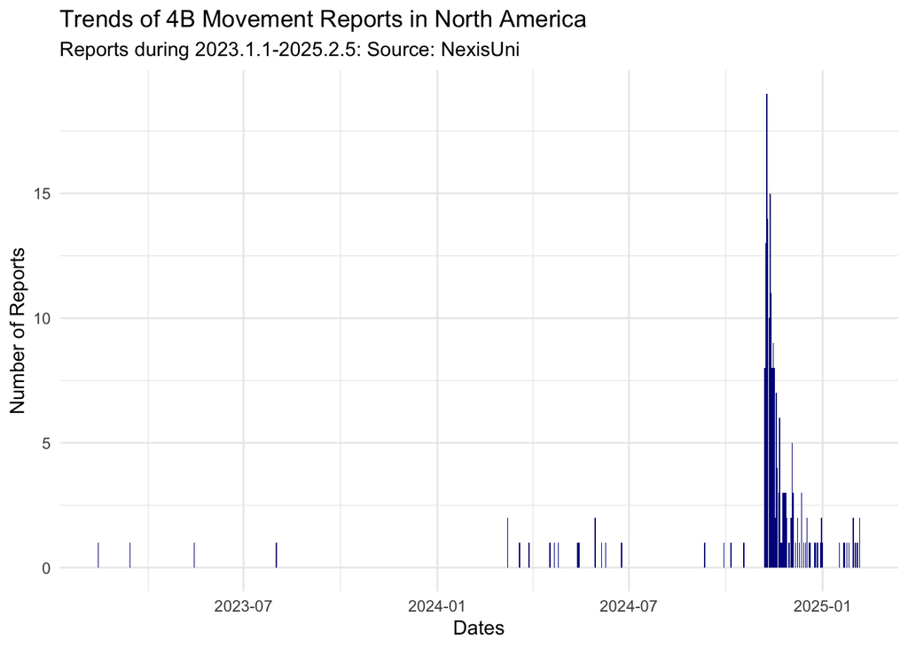

### Trends of Social Media

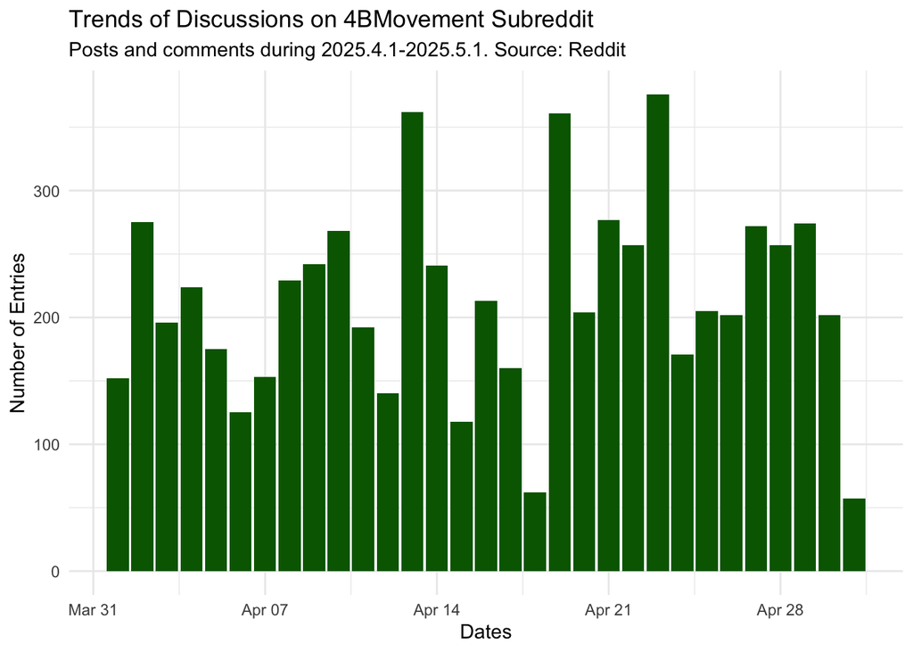

#### Summary of Trend

First, this study examines the **trends in news coverage and online discussions** related to the 4B movement.

Most of the **news articles** were published **during the presidential election period**, with about 5 to 15 articles each day during that time. Before and after the election, the 4B movement was rarely mentioned. This suggests that, in the eyes of mainstream media, 4B was seen as a fleeting reaction to the election or a debate topic between political parties, rather than a real or ongoing issue worthy of attention.

## Result 2: Bigrams & KWIC – Who or What Is the Subject of 4B?

### Bigrams from Newspapers

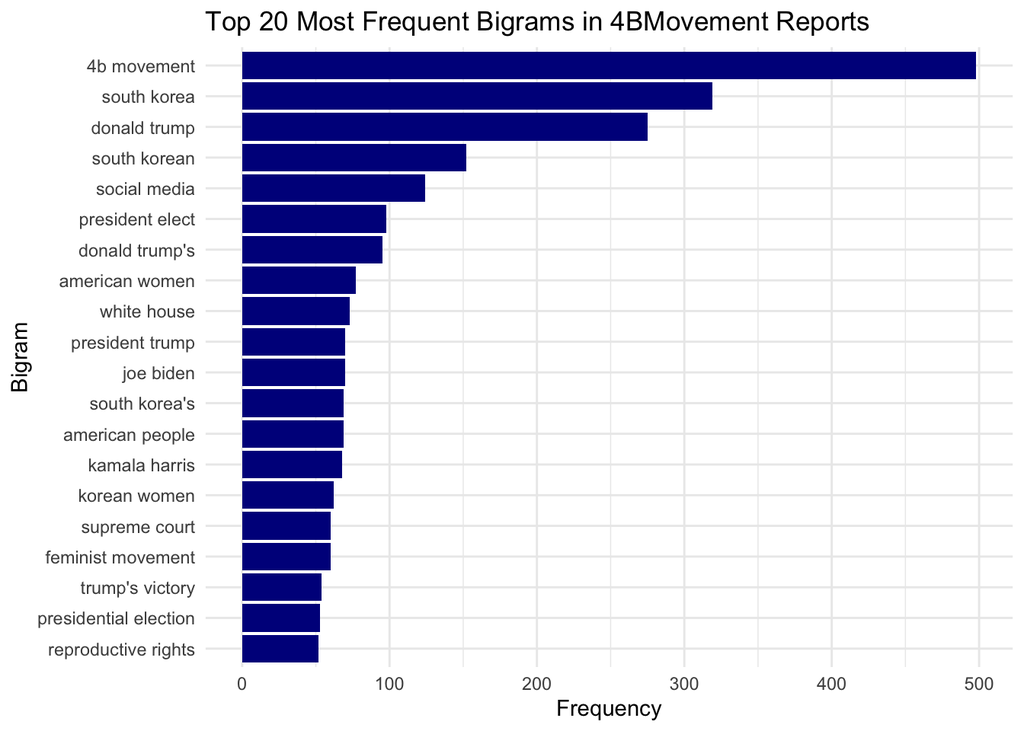

### Bigrams from Social Media

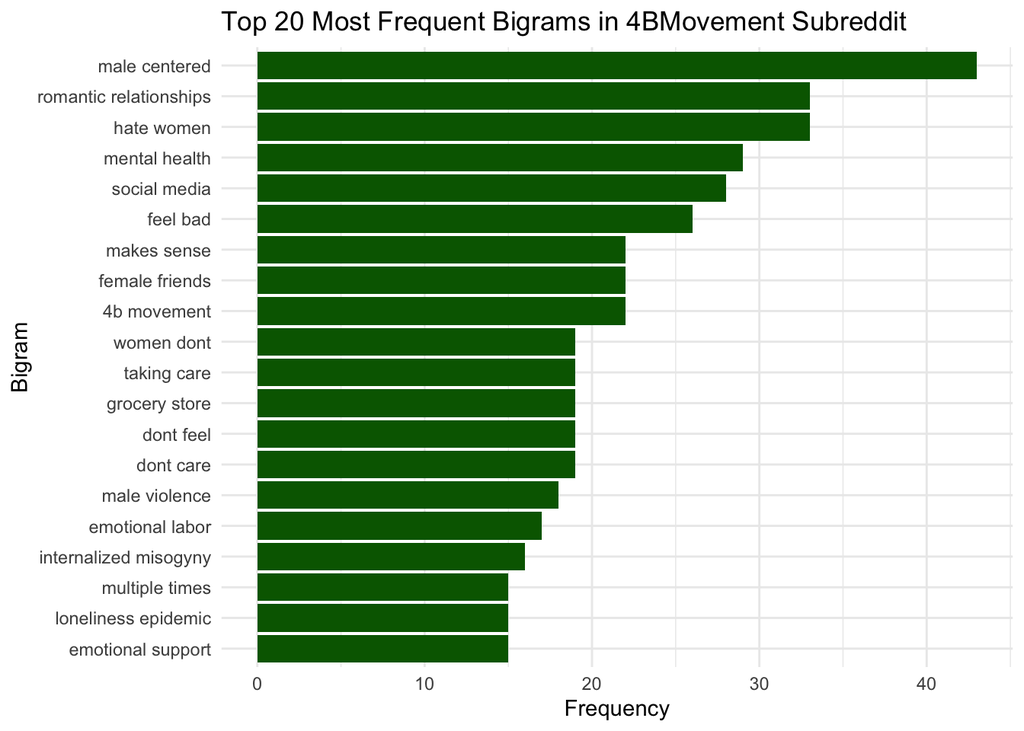

#### Summary of Bigrams

Here, I examined the most frequently occurring bigrams in both news articles and online discussions. After removing meaningless or irrelevant phrases such as “video clip” and “http www.reddit.com,” I listed the top 20 most common bigrams in each dataset.

In the news articles, most of the top bigrams were related to the **4B movement** itself, its **social context** (such as its origin in South Korea), and various **political figures or events** in the US.

In online discussions, the most common bigrams focused on **men, women, friends, and relationships**, as well as phrases that criticized patriarchy and heteronormative norms, such as **male-centered, hate women, and internalized misogyny**.

These bigrams help reveal the main subjects of the reports and discussions. To further understand the specific meanings and contexts of these terms, I next use **KWIC analysis** to closely examine what adjectives are associated with those subjects.

### KWIC with Newspapers

#### Word Cloud for 4B movement

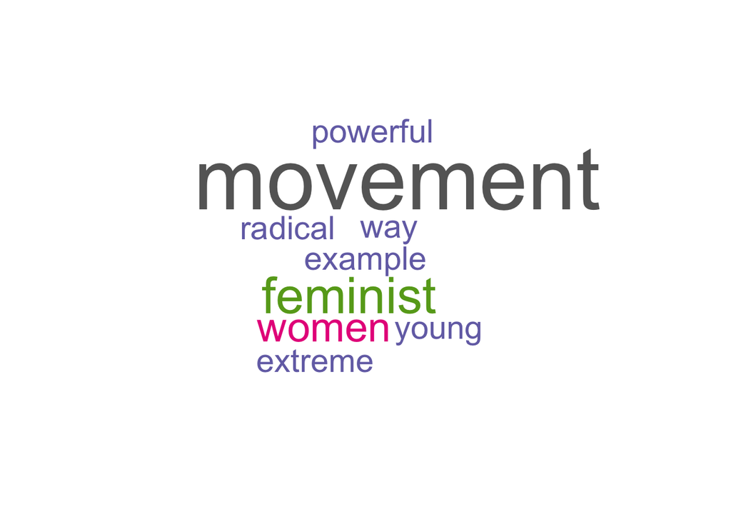

#### Word Cloud for Donald Trump

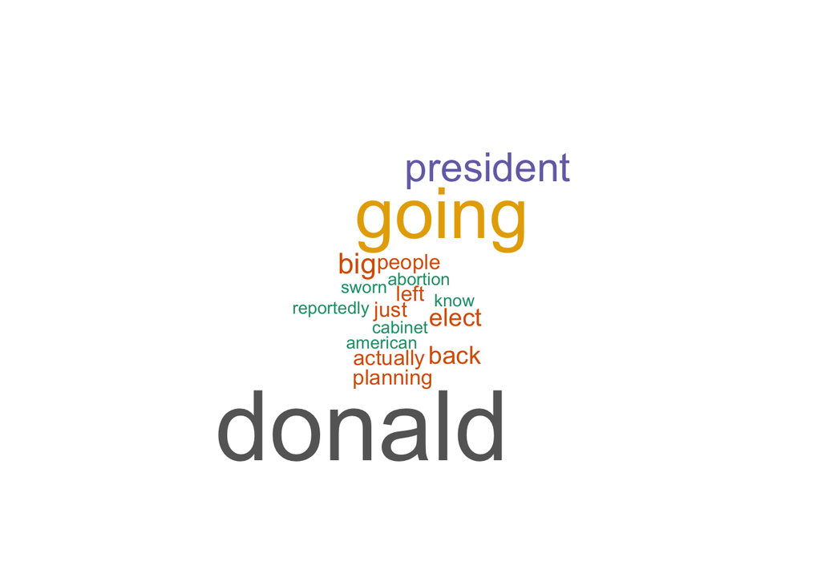

### KWIC with Reddits

#### Word Cloud for Men

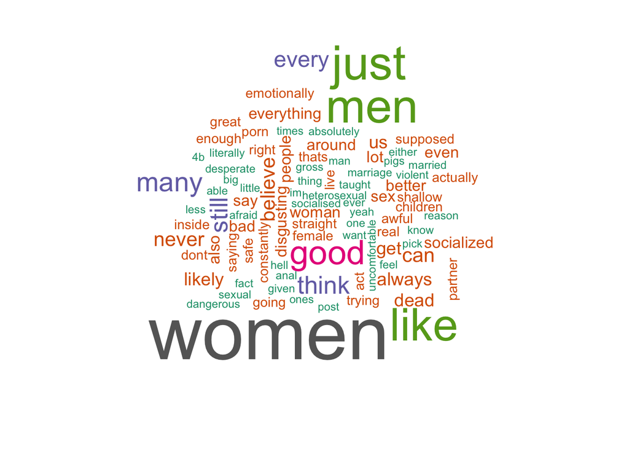

#### Word Cloud for Relationships & Marriage

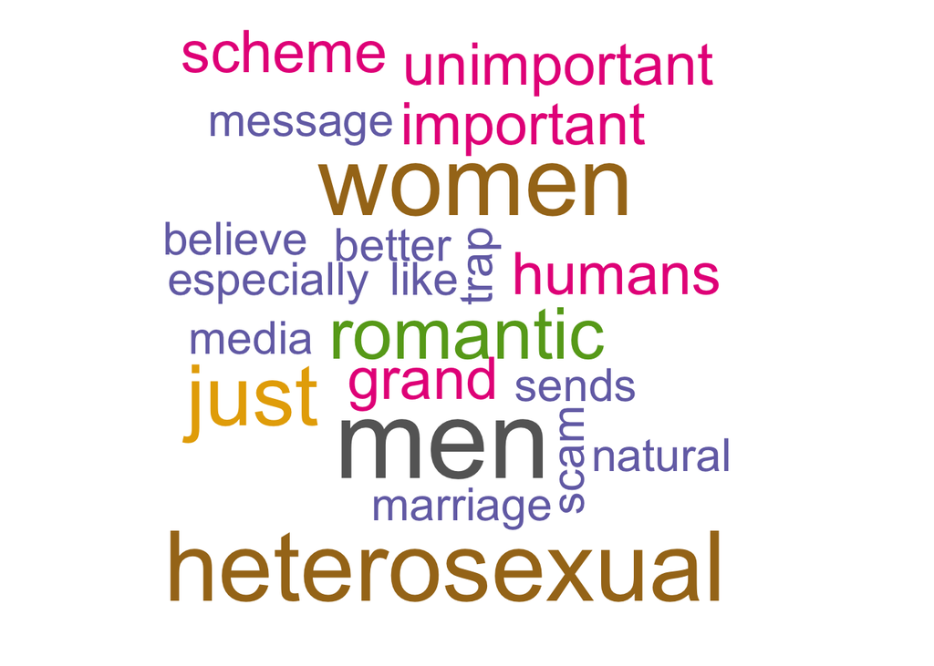

#### Summary of KWIC

Based on the top 20 bigrams from newspaper reports, the most common subjects are the “4B movement” and “Donald Trump.” I used KWIC analysis to examine the adjectives surrounding these terms. The results show that 4B-related news often mentions **Trump’s return** to the presidency, and the **4B movement** is frequently described as **feminist and extreme**.

In Reddit discussions, the most frequent bigrams center around “men” and “relationships.” KWIC analysis reveals that **men are often portrayed negatively**, with adjectives like desperate, uncomfortable and violent. Meanwhile, **marriage and romantic relationships**, especially heterosexual ones, are frequently framed as a **trap** or as **unimportant**.

## Result 3: Sentiment Analysis - How Does 4B Feel About Sex, Romance, and Men?

#### Sentiment Analysis for Newspaper

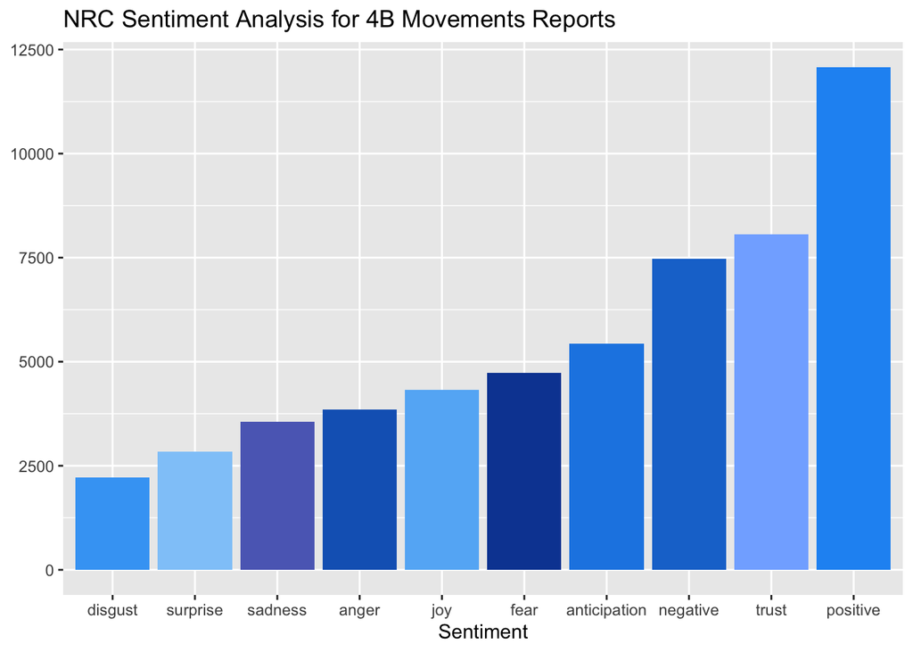

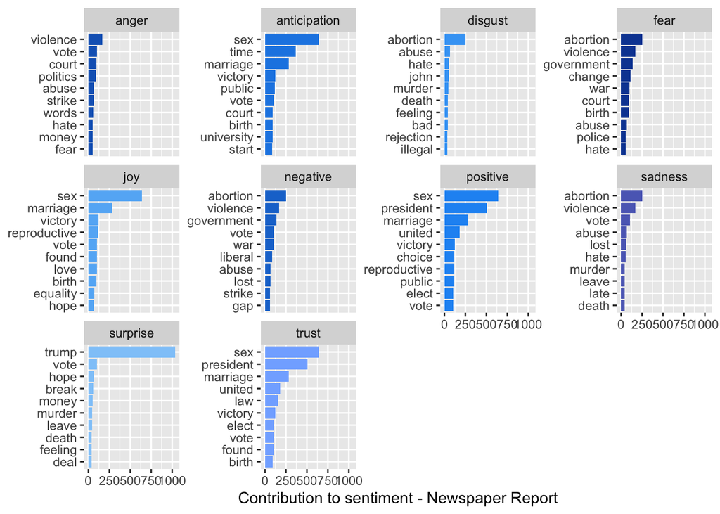

#### Sentiment Analysis for Reddit Discussions

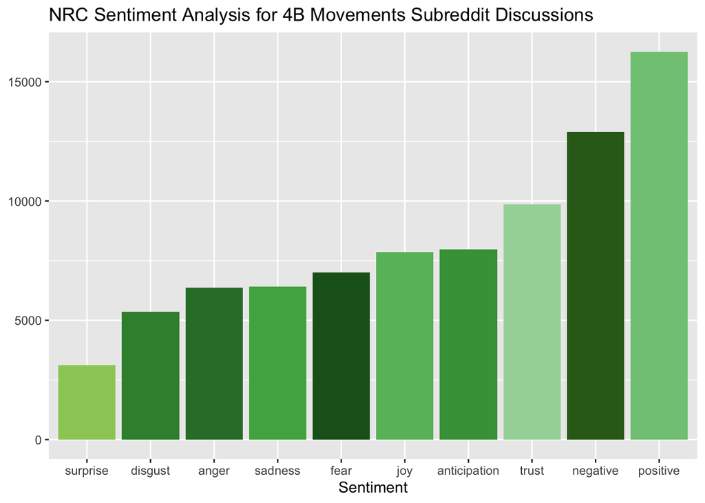

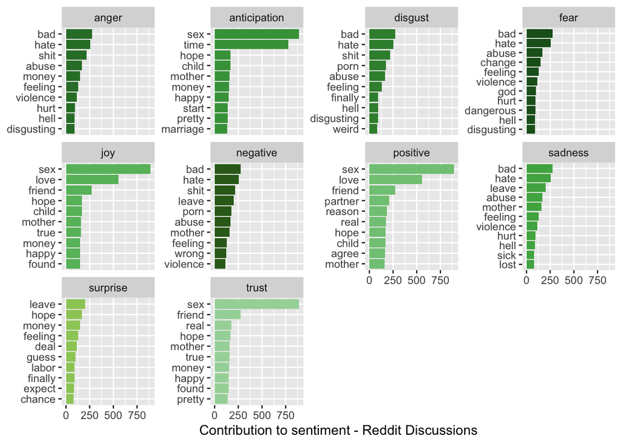

#### Examine the positive sentiment

##### Word Cloud for Sex in Newspapers

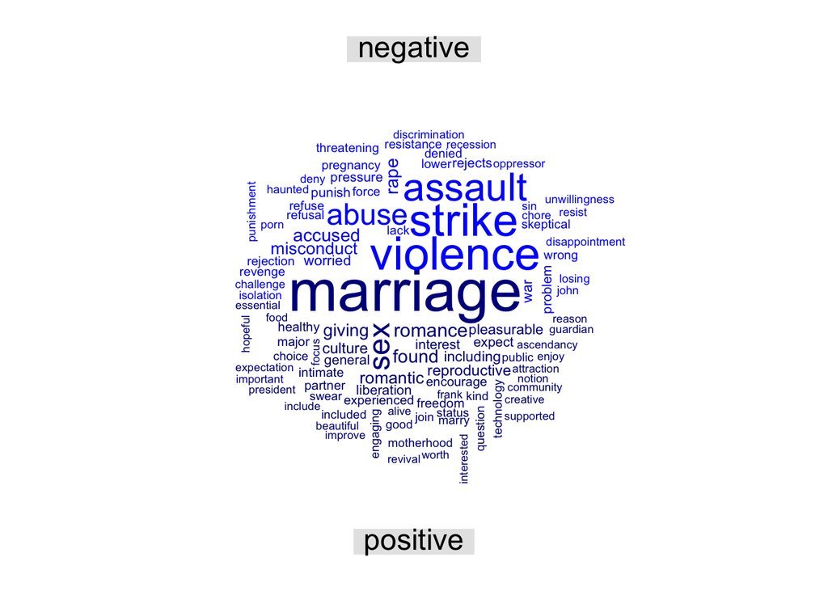

##### Word Cloud for Sex in Reddit

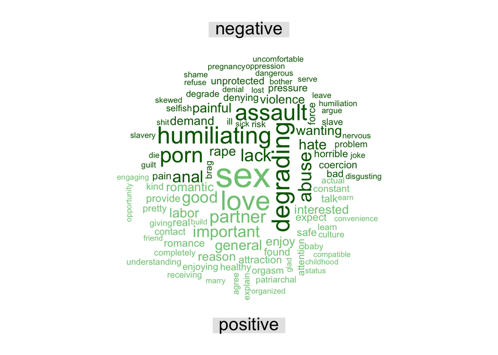

#### Summary of the positive sentiment analysis

Both the sentiment analysis of news reports and online discussions show that **positive is the most common sentiment**, with trust and anticipation as the leading sub-sentiments. For each of these positive sentiments, **sex** emerges as the most contributing word. This reflects that in the NRC lexicon, sex is categorized as a positive term, associated with joy, trust, and anticipation.

However, when I actually read the original online discussions, I noticed that sex was often not discussed in a positive way by 4B participants. This made me question **how accurately** the positive sentiment analysis captures the tone and meaning of these discussions and reports.

To explore this further, I used KWIC and generated two word clouds to examine **what kinds of words typically appear in the context of sex**.

Based on the two sentiment word clouds, it’s clear that sex is definitely not being discussed in a genuinely positive way.

In newspaper articles, discussions of sex often appear alongside terms like **violence, assault, abuse, and rape**. This may reflect one of the core reasons why 4B participants reject sex with men. Another commonly appearing phrase is **sexual strike**, which reflects how the 4B movement was portrayed by American media.

In online discussions, leading words include **humiliating and degrading**, reflecting how 4B participants perceive heterosexual sex. Other frequently co-occurring words are **abuse, painful, porn, and assault**, which also help explain why they view sex in this way.

In conclusion, I believe it’s fair to say that the sentiment analysis **overestimates the positivity** in both the articles and the online discussions.

#### Examine the negative sentiment

##### Quotes from Reddit: violence and hate

“ I don’t hate men the same way men hate women. ”

“ When women say they hate men, they want nothing to do with them. ”

“ What you’re describing isn’t the hatred of men but the violence and sexism you have received from men. ”

“ A world where we are never truly safe from male violence. ”

“ Decentering them does not exclude us from their violence. We need to keep ourselves safe. ”

#### Summary of the negative sentiment analysis

For the negative sentiment analysis, the most common words in newspapers are **hate, violence, abuse, abortion, murder, and strike**. In Reddit posts, the top negative words include **hate, abuse, violence, and porn**.

My next step was to identify whether these words actually represent negative sentiment in context. To do this, I selected a few sentences that included the words **hate or violence**.

These sentences express women’s negative emotions toward men, while also providing context for those feelings, that is, the experience of violence and harm.

Second, 4B participants seem to try to redefine the concept of hate. They view men’s hatred of women as more active, violent, and malicious, while women’s hatred of men as a reaction and an expression of indifference or emotional detachment.

Overall, based on my observations, the negative sentiment analysis seems more accurate in capturing the tone of these discussions. Although the original analysis identified positive sentiment, especially trust and anticipation, as the most common, my further investigation suggests that negative emotions, particularly fear and anger, may actually be more dominant.

What is the final takeaway for sentiment analysis?

#### Summary of Sentiment Analysis

I believe the **inaccuracy of sentiment analysis** in this case actually reflects a core feature of the 4B movement, that is, its emphasis on **deconstructing and redefining dominant social and gender norms**.

In traditional patriarchal and heteronormative cultures, **marriage, romantic relationships, and sex** are typically seen as **desirable and normative**. **Men** are viewed as the **stronger and superior** gender, both socially and relationally, and often perceived by women as **cooperative and attractive**.

However, within 4B discourse, these ideas are turned upside down. **Sex**, especially heterosexual sex, is seen as something that primarily serves men, while being **degrading** and frequently associated with **violence** for women. **Marriage and romance** are portrayed as **unimportant, deceptive, or as symbols of patriarchy**, representing the exploitation and oppression of women. **Men**, in this discourse, are often associated with **violence, danger, and unattractiveness**, reflecting a kind of **gender separatism**.

## Result 4: Topic Modeling – What Are the Main Topics of 4B?

#### Topic model for Newspaper Reports

##### Quote from Topic 1: Trump & Politics

But first, the Trump transition team continues to fill key roles in the upcoming administration. The president-elect is expected to announce Stephen Miller, his top immigration adviser, as White House deputy chief of staff for policy. Vice President-Elect J. D. Vance calling it, another fantastic pick. Former New York Congressman Lee Zeldin has been picked to the administrator of Environmental Protection Agency. Zeldin says, quote, “We will restore U.S. energy dominance.”

##### Quote from Topic 2: 4B Origins

The 4B movement, a radical feminist initiative originating in South Korea, challenges traditional gender dynamics by advocating for a complete rejection of relationships with men. The name 4B is derived from the Korean word “bi,” meaning no, as each of the movement’s four principles begin with this syllable. The key tenets of 4B include “bichulsan” (no giving birth), “bisekseu” (no heterosexual sex), “bihon” (no marrying men), and “biyeonae” (no dating men). The movement emerged in response to violence against women, online misogyny and laws promoting childbirth and marriage, which aim to address South Korea’s incredibly low birth rate.

##### Quote from Topic 3: Other Contexts

GREGG JARRETT, FOX NEWS LEGAL ANALYST: Yeah. The defense is destroying the prosecution. It was already an anemic case, as the professor pointed out. And you know, today’s medical expert really blew a gigantic hole in the prosecution when he tells the jury Neely didn’t die from the chokehold, but he had enough drugs in his system to drop an elephant.

##### Quote from Topic 4: 4B in US Online

This is in line with many of the conversations I’ve had with friends recently. None of us are ready to remove ourselves entirely from heterosexual relationships. We’re enjoying focusing on other things like friendships, travel, and family without the distraction and emotional labour of dating. Focusing on these areas feels more fulfilling, especially as life becomes busier. After all, my best friend or sister isn’t likely to ghost me. Dr. Jess O’Reilly, Tinder’s Canadian relationship expert, is also not surprised by the U of T study results. She explains they echo findings from Tinder’s 2023 “Year in Swipe” and “Future of Dating” reports, indicating a substantial shift toward selfprioritization and independence among gen Z and millennial women.

##### Quote from Topic 5: Abortion & Politics

For some women in the U.S., the 2024 election felt like a critical moment for the future of reproductive rights. Trump - who took credit for overturning Roe v. Wade - cast a shadow of uncertainty over bodily autonomy. Google searches for 4B have surged over the past week as women seek ways to regain a sense of empowerment amid political upheaval.

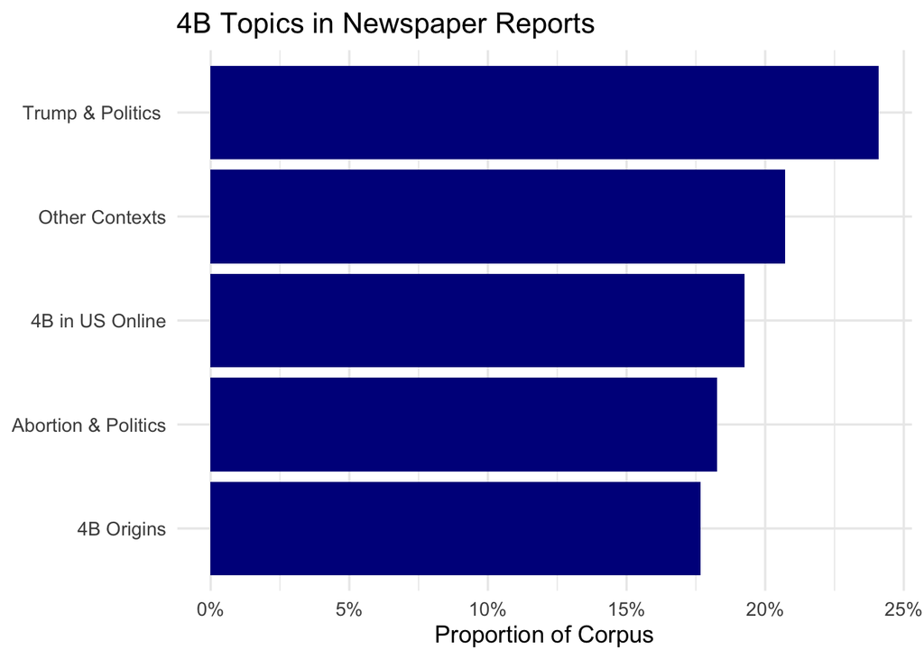

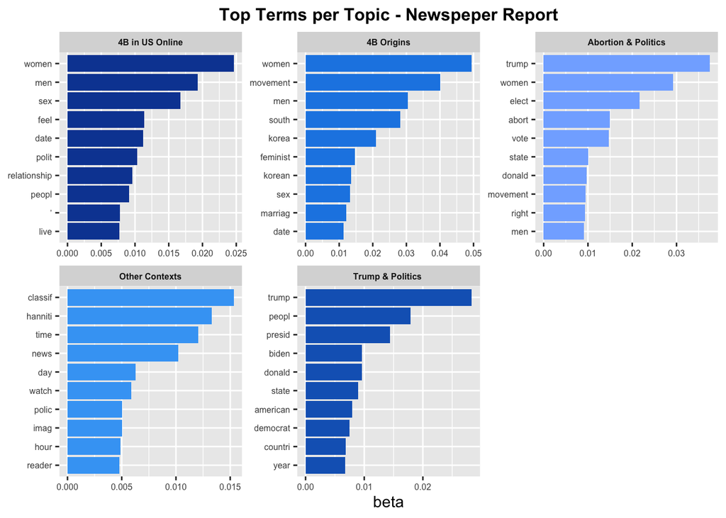

##### Summary of Topic Modeling on Newspaper Report of the 4B Movement

In analyzing U.S. media coverage of the 4B movement, I tested models with 4 to 7 topics and ultimately selected the **5-topic** version.

First, some news articles mention the 4B movement as a **side example** in the context of **presidential election debates**, rather than engaging with it in depth. 1) In Democratic discourse, 4B is often connected to **abortion rights**. 2) In contrast, Republican commentary tends to **mock or dismiss** the movement. For example, one commentator said: “I still can’t get over the 4B movement… women that are cutting their hair and putting it on social media… pledging to never have sex with their husband… divorcing their husbands if they voted for Donald Trump…”

In articles **focused specifically on the 4B movement**, 1) one theme highlights its **origins in South Korea**, where it emerged as a response to deeply rooted patriarchy and gender-based violence, including hate crimes against women in public spaces. 2) Another theme centers on **American 4B participants**, who are often active on platforms like TikTok and whose involvement is closely tied to Trump’s presidential election.

Overall, U.S. media coverage of the 4B movement is highly related to its political background.

#### Topic model for Reddit Discussions

##### Quote from Topic 1: Patriarchal Family & Marriage

I just watched my parents together today and their marriage is miserable. My dad is passive, childish, messy, a workaholic, and absent from both my mother and kids lives. My mom will ask him to do something and he does it wrong. Shes growing more and more bitter/sad as the years have gone by. I dont think she ever envisioned a life for us kids where the father, her husband, couldnt care less about us. She carries such pain and guilt for not breaking the cycle of her generational trauma (absent father & strong/overbearing women). I see it weigh on her and I see the jealousy of her daughter, my sister, with her new husband. If this is marriage and life with a man, I want no part of it. =

##### Quote from Topic 2: Feminist Discourse

Id recommend Laura Bates. She writes brilliantly about sexism and misogyny. Particularly her book Men Who Hate Women she has a new one coming out about sexism and AI later this year.

##### Quote from Topic 3: Male Violence & Blame on Women

it’s both. even in matriarchal and matrilineal societies, men abuse and exploit women (see the Musuo people for a specific case study, but there’s many many others). most modern societies are patriarchal and therefore set up to, as you say, lack consequences for male behavior. that doesn’t mean there isn’t a biological tendency toward these behaviors. for millennia men have acted this way and they always will. the social factor is partly conditioning, but it’s majorly that we don’t designate this behavior as unacceptable.

##### Quote from Topic 4: Heterosexual Sex

My post and my problem with sex is the biological submission and humiliation like Doggystyle aka bowing down with your ass up completely exposed and head down, penetration , sucking dick or serving dick, vulnerability of the female body and not societal

##### Quote from Topic 5: Men Hygiene

Yeah, my story is that my STBX husband would only brush his teeth once in the morning when he showered. He would get ready for bed by using the bathroom, with the door open, often having explosive bowel movements. Not wash his hands, and then come to bed, expecting sexy times >“He is a fucking doctor. No amount of asking, begging or shaming could convince him to shower, brush his teeth, or at the very least, wash his hands. Gross.

##### Quote from Topic 6: Romantic Fantasy & Male Desire

Im the same way. I love romance in fiction. Its easy when the men are written by women! = I used to be attracted to men like most women when I was younger but its like as I got older and Im only 25 I feel zero attraction. A mans looks is not enough to make me feel anything as Im more attracted to personality and character and when men dont have that attraction is impossible. I have also realized over time that you can be attracted to men but that doesnt mean you will feel this peak happiness of a relationship everyone tells you you will feel. Im more satisfied in romantic fiction then any man I have had in real life. I also value my freedom and Im not too happy with the idea of sacrificing even the tiniest bit for a man.

##### Quote from Topic 7: Harassment & De-Beautifying

Oh yeah. Definitely stop shaving your legs and under arms. Stop wearing makeup, stop trying to look cute, I only give compliments to other women.

##### Quote from Topic 8: Friendship & Boundaries

I think it important to have friends from all walks of life not just those who have the same interests and values as me. Even people having the same values doesnt mean theyll connect and grow a deep friendship. Nobody is a perfect amalgamation of the values we find important. Sometimes people change their minds about how they want to live their lives. However, if this person doesnt trust you enough to update with new changes in their life I think you have to evaluate if the depth of friendship was mutually shared. Have an honest reflection if you were pushing too harshly for ideals without checking in with your friends feelings. It can be off putting and push people away from you. Focusing on developing a deeper connection with your self and developing the quality of your friendships relationships is beneficial for understanding what you need and what you bring to others.

##### Quote from Topic 9: Abusive Relationships

You don’t need to feel guilty. You didn’t decide that he would act in an abusive way. I hope you can heal from these horrible things and I am glad that you can go no contact completely.

##### Quote from Topic 10: Life Beyond Sex and Romance

I enjoy reading, rpg video games, hiking, and trying new recipes.I sometimes garden, attempt to learn how to draw and blend with pencils, and paint.Lifestyle wise I do a lot of strength training and meditation.

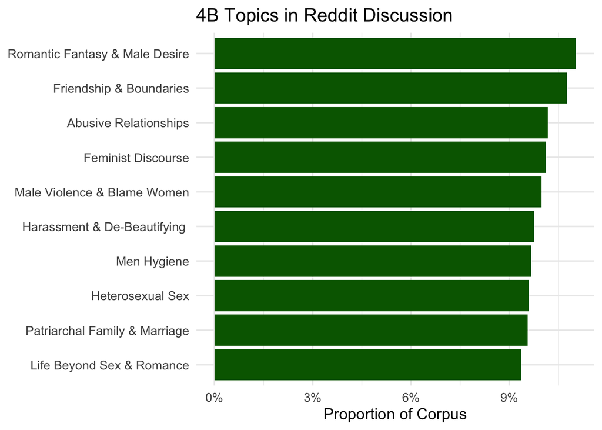

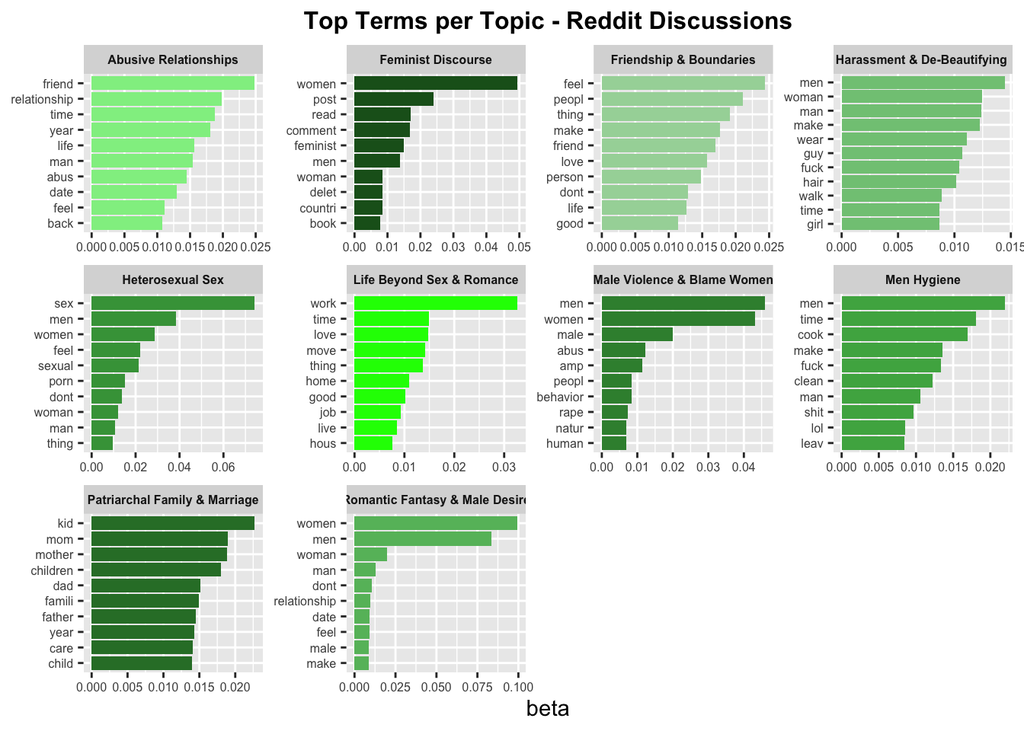

##### Summary of Topic Modeling on Online Discussions of the 4B Movement

In conducting the topic modeling, I explored models ranging from 5 to 10 topics. I ultimately chose to present the **10-topic** version, as I believe the online 4B movement contains rich and nuanced discussions that deserve a more detailed thematic breakdown.

The **first** thematic cluster centers on **critiques of patriarchal culture**. The targets of criticism include: 1) **heterosexual sex**, especially acts like penetration and oral sex, which are viewed as inherently degrading to women; 2) **heterosexual relationships**, where women are fed idealized fantasies through media and fiction, while men often exhibit a contradictory mix of misogyny and desperate desire for women; 3) **marriage and family structures**, which expect women to sacrifice their own development to take on unpaid and devalued labor such as childbirth and housework; 4) **misogynistic cultural narratives**, which normalize male violence while blaming and shaming women for male’s mistakes.

In the **second** part, women share their **everyday experiences with men**, including: 1) **poor hygiene** and a lack of domestic responsibility in daily life; 2) **abusive relationships**, either personally or through friends. 3) and **harassment in public spaces**;

Third, **friendship** emerges as a distinct theme. Many participants talk about having female friends who are stuck in toxic relationships but unwilling to leave. On one hand, they express the **emotional exhaustion** of constantly being expected to offer support, which leads to a strong need to set boundaries. On the other hand, they highlight the importance of investing in **friendships with shared values**.

Finally, participants also shared their **lives that are not centered around sex or romantic relationships**. This includes: 1) **feminist reading and discussions**; 2) friendship, leisure, work, and **other aspects of everyday life**.

In summary, news reports related to the 4B movement mainly focus on the political context in the United States as well as the origins of the movement and the profiles of its participants.

In contrast, online discussions around 4B are more centered on critiques of patriarchy and its manifestations in sex, romantic relationships, marriage and family, and broader cultural norms. These discussions often stem from women’s negative experiences with men in daily life, intimate relationships, and public spaces. These discussions further reflect a desire to explore alternative ways of living that are not centered around sex or romantic love, and that are separated from men.

## Conclusion

This project explored how the 4B movement is represented in mainstream media and discussed in online spaces. Using bigram analysis, sentiment analysis, and topic modeling, I addressed several key questions: Is the 4B movement a real phenomenon in the English-speaking world? What are its main subjects? How do participants feel about traditional notions of sex, romance, and men? And finally, what are the main topics of discussion?

The findings highlight a striking contrast between institutional and grassroots narratives. In mainstream media, the 4B movement is largely depicted as a marginal and short-lived phenomenon, often tied to the presidential election cycle rather than recognized as a sustained or legitimate movement. Such reports tend to dismiss the 4B movement as extreme or reactionary, or use it as a tool in political debates, rather than taking its ideological stance seriously.

In contrast, Reddit discussions reveal that the 4B movement operates as a dynamic and evolving discourse community in the English-speaking world. On one hand, participants deconstruct traditional cultural paradigms that are deeply rooted in patriarchal norm, includeing heterosexual romance, sex, and marriage. This deconstruction is grounded in widely shared personal and collective experiences of gender-based violence in both public and private life. On the other hand, participants attempt to redefine foundational concepts such as sex, men, romantic relationships, and marriage. The movement also imagines and builds a lifestylf that is not centered around sex or romantic relationships, but instead focused on friendship, women’s communities, hobbies, self-growth, and autonomy.

Overall, I think the 4B movement shows how feminists are trying to break away from patriarchal and heteronormative norms in their personal lives and create new ways of living. While the movement is still relatively small in the English-speaking world, it may grow in the future, just as staying single or choosing not to have children has become a very common lifestyle among young people in China and South Korea.

#### Limitation & Future Direction

First, the dataset of online discussions only covers a short period (from April 1st to May 1st), which fails to capture the full picture of online 4B discussions. In future research, I plan to collect the complete posts and comments from the 4Bmovement subreddit and analyze the trends in topics and sentiments over time.

Second, the current analysis is more empirical than theoretical. In the future, I aim to engage more deeply with feminist theory and employ the framework of counterpublics to better explain and interpret the findings.

#### Acknowledgments

First, I truly appreciate everything I’ve learned from this class, and I’m especially grateful for the support I received from Dr. Wells. This has been an amazing experience—super helpful, informative, insightful, and easy to follow. I’ve learned so much.

Second, I want to thank my classmates for their thoughtful feedback and for generously sharing their code.

Third, I used ChatGPT-4o to debug my codes.

#### Reference

Lee, J., & Jeong, E. (2021). The 4B movement: Envisioning a feminist future with/in a non-reproductive future in Korea. Journal of Gender Studies, 30(5), 633-644.